# Creating Images with R

The Cool Coding Cat In Sunglasses

Eirene Lee

```css
/* 1. Change the background color of the whole page */
body {
  background-color: #E0E7FF;
  font-family: 'Helvetica Neue', Helvetica, Georgia, Verdana, sans-serif;
}

/* 2. Change the appearance of second-level headings */
h2 {
  color: #020035;
  border-left: 5px solid #ffd700; /* A gold bar to match the meme theme */
  padding-left: 10px;
  text-transform: uppercase;
}

/* 3. Style the image display area */
img {
  border: 3px solid #2c3e50;
  border-radius: 12px;
  box-shadow: 0px 4px 20px rgba(255,215,0,0.2);
  margin-bottom: 25px;
}
```

## Project requirements

Below is a screenshot showing that I have correctly set up my RStudio Project and organized my files:

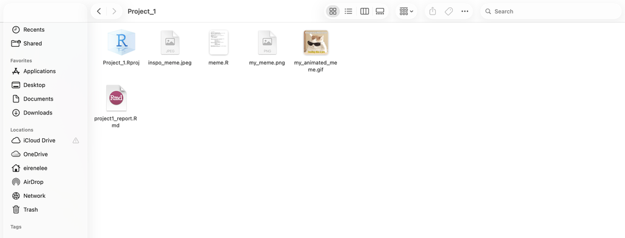

RStudio Project Folder

My work for this course is tracked and shared on GitHub: [Link to my stats220 GitHub Repository](https://github.com/elee08/stats220)

## Inspo meme

[figure not shown]

Original Inspiration Meme, A calm calico cat wearing round dark sunglasses with the text ‘NO STRESS’ at the top and ‘JUST VIBING’ at the bottom

The “inspo” meme is a classic example of modern internet humor that relies on a minimalist yet effective visual hierarchy. The primary subject is a high-resolution, centered image of a long-haired calico cat captured with a shallow depth of field, which keeps the viewer’s focus entirely on the cat’s “cool” persona established by its small, round black sunglasses with metallic frame. Strategically placed at the top and bottom of the frame is the text “NO STRESS” and “JUST VIBING,” rendered in the iconic, bold Impact font. This typography utilizes a high-contrast white fill with a thin black outline (stroke), ensuring the message remains perfectly legible against both the light fur of the cat and the neutral tan background. Together, these components create a balanced composition that communicates a relatable theme of relaxed confidence.

## My meme

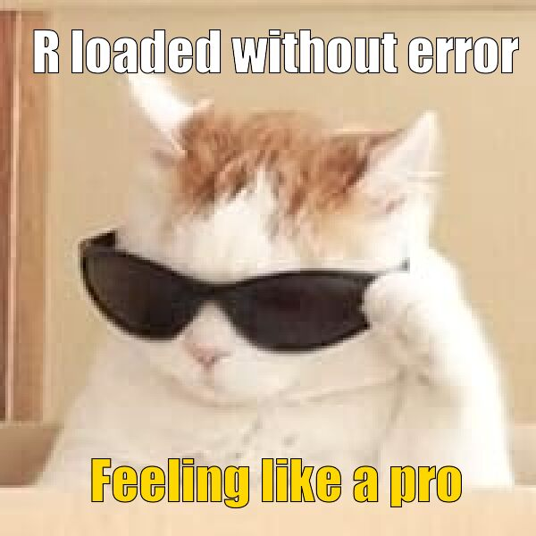

My custom R-generated meme featuring a cat in sunglasses with the text ‘R loaded without error’ and ‘Feeling like a pro’

Changes and Justification I have modified the original “inspo” meme in several key ways to adapt it to my personal academic experience:

Image Replacement: I replaced the centered calico cat with a different image of a white and orange cat wearing larger, dark “sport” sunglasses. I chose this image because the cat’s paw is positioned near the glasses, suggesting a “cool” or “calculated” gesture that fits the feeling of a successful coding session.

Text Content: I updated the text from “NO STRESS / JUST VIBING” to “R loaded without error” at the top and “Feeling like a pro” at the bottom. As a student in Statistics, this change reflects the specific relief and sense of achievement that comes when complex code runs perfectly on the first try.

Typography and Color: While I kept a bold, Impact style font to maintain the meme aesthetic, I changed the color of the bottom text to a vibrant gold with a black outline. I chose gold to visually represent a “gold standard” or “pro” status, making the punchline stand out more than the white text used in the original.

## My animated meme

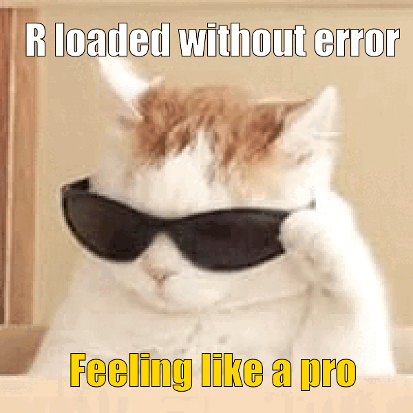

My animated The Cool Coding Cat In Sunglasses meme GIF

## Creativity

Creativity My project demonstrates creativity by going beyond the basic requirements of the lab in several ways:

Advanced CSS Implementation: I used more CSS than required to significantly enhance the communication of my report, including a themed indigo background (#E0E7FF) and a custom gold border-left for headings that aligns with the visual identity of my meme.

Custom Color Theory in CSS: I went beyond the required three CSS changes by implementing a cohesive color palette that uses RGBA transparency for the image shadows (rgba(255,215,0,0.2)), which creates a modern “glow” effect that matches the overall aesthetic.

Extended {magick} Functionality: I explored and implemented functions from the {magick} package that were not explicitly covered in the core lectures, such as image_negate() to create a high-contrast visual “flash” and image_rotate() to add a celebratory dancing motion to the cat’s frames.

Personal Context Integration: I incorporated specific personal context, transforming a generic “cool cat” into a representation of the professional satisfaction felt when complex R code executes without errors.

## Learning reflection

One Important Idea from Module 1 The most eye opening part of this module was realizing that HTML isn’t just a coding language for “web developers” it’s a powerful tool for anyone working with data. Before this, I saw web design and data analysis as two completely separate worlds. Learning how modern technologies allow us to wrap our raw data and code into a clean, interactive HTML shell changed my perspective. It’s one thing to run a script in a console, but it’s another thing entirely to present that work in a way that is structured, accessible, and professional. Seeing how a few lines of CSS can take a cluttered report and turn it into something readable and organized made me realize how much “presentation” actually matters in science.

Future Explorations in Data Technologies Looking ahead, I’m really curious about how we can use these technologies to make complex biological or statistical data more “human.” I’d love to explore how to build more interactive dashboards where a user can actually play with the variables to see how a model changes in real time. Since I’m interested in the intersection of biology and data, I’m also keen to learn more about how we can use web based tools to visualize large scale genomic datasets or clinical results. Moving from just “calculating” numbers to “communicating” them through well designed digital platforms is a bridge I’m excited to keep building.

## Appendix

Do not change, edit, or remove the `R` chunk included below.

If you are working within RStudio and within your Project1 RStudio project (check the top right-hand corner says “Project1”), then the code from the `meme.R` script will be displayed below.

This code needs to be visible for your project to be marked appropriately, as some of the criteria are based on this code being submitted.

```r
library(magick)

#Part D
#Reading the image
#Sourcing a blank version that look like the inspo cat
#Note to self: named object inspo_meme

inspo_meme<- image_read("https://i.gr-assets.com/images/S/compressed.photo.goodreads.com/users/1693744492i/169553571._UY200_CR1,0,200,200_.jpg")

#Developing the meme
#Using pipes (%>%), white space, and indentation for readability
#Function 1: Scaling image
my_meme<- inspo_meme %>%
  image_scale(600) %>%


  #Function 2: Top line set font to Impact(Add top text)
  image_annotate(text="R loaded without error",
                 size = 60,
                 color = "white",
                 strokecolor = "black",
                 font = "Impact",
                 location = "+35+20") %>%
  #Function 3: Add bottom text, same font (punchline)
  image_annotate("Feeling like a pro",
                 size=60,
                 color="gold",
                 strokecolor = "black",
                 location = "+100+500",
                 font= "Impact")
#Save the meme
#R code that same my meme as an image file named "my_meme.png"
image_write(my_meme, "my_meme.png")

#Part E
#Note to self: reuse the static meme object 'my_meme' from Part D
#create at least 4 frames to show animation

#Frame 1: The original
frame_1 <- my_meme

#Frame 2: Flash
#note to self: use image_modulate to change the brightness
frame_2 <- my_meme %>%
  image_modulate(brightness=170)

#Frame 3: Inverting colour for a cool effect
#note to self: use image_nagate
frame_3<- my_meme %>%
  image_negate()

#Frame 4: Final celebration
#note to self: use image_rotate to make the cat tilt in excitement
frame_4<- my_meme %>%
  image_rotate(20) %>%
  image_scale(600) #Scaling image back to original size after rotation

#Combine the 4 frames into a single object
#Requirement: use of the c() function
meme_sequence <- c(frame_1, frame_2, frame_3, frame_4)

#Create animation
#Requirement: use of  image_animate() with a set frame rate
my_animation <- image_animate(meme_sequence, fps = 2)

#Save the animated GIF using the required file name
#Requirement: use of image_write()
image_write(my_animation, "my_animated_meme.gif")
```